# Practical 5 - Longitudinal data analysis using `R-INLA`

Bayesian modelling for spatial and spatio-temporal data

In this practical we will carry out a longitudinal analysis using data on individuals collected over time. The data are included in the R package `brinla`, which contains data and R code from the book by Wang, Yue, and Faraway (2018) available at the website: https://julianfaraway.github.io/brinlabook/index.html

The longitudinal data that we are going to use are from Singer and Willett (2003) and concern reading scores (PIAT = Peabody Individual Achievement Test) measured on n = 89 children at ages 6.5, 8.5 and 10.5 years of age. We expect scores on the same student to be correlated, and as we saw in this week lecture, one way of acknowledging this is to include a random intercept in the model.

To start with, create a separate subdirectory to save your files created during this practical (e.g. setwd(“~/Practicals/Practical5”)).

# 1. Install and load packages

- This practical requires the installation of package `brinla` via `devtools`. Install the `devtools` R package if you have not already done so.

```r
library(devtools)
remotes::install_github("julianfaraway/brinla")
```

- Then, load the needed packages:

```r
library(INLA)
library(brinla)
library(ggplot2)
library(dplyr)

# For tables in RMarkdown
library(knitr)
library(kableExtra)
```

# 2. Description and visualization of the data

- We start by loading the data

```r
data(reading, package = "brinla")
```

- Inspect the first rows of the data set `reading`

```r
head(reading)
```

```
##   id agegrp piat
## 1  1    6.5   18
## 2  1    8.5   35
## 3  1   10.5   59
## 4  2    6.5   18
## 5  2    8.5   25
## 6  2   10.5   28
```

Note that $ID$ is the identifier for each student

- We now see an alternative and more elegant way to print the first five rows of the data, formatting these in a table. RMarkdown by default displays data frames and matrices as they would be in the R terminal. To display a table with additional formatting, we can use the `knitr::kable` function:

```r
kable(reading[1:5,], booktabs = T) %>%
  kable_styling(bootstrap_options = "striped", full_width = F, position = "center")
```

| id | agegrp | piat |
| --- | --- | --- |
| 1 | 6.5 | 18 |
| 1 | 8.5 | 35 |
| 1 | 10.5 | 59 |
| 2 | 6.5 | 18 |
| 2 | 8.5 | 25 |

Note: to know more about this function, you can type in the console `?knitr::kable` and visit the page https://haozhu233.github.io/kableExtra/awesome_table_in_pdf.pdf

- We visualize the data using `ggplot2`, showing how the reading score of the students vary across three ages of measurements

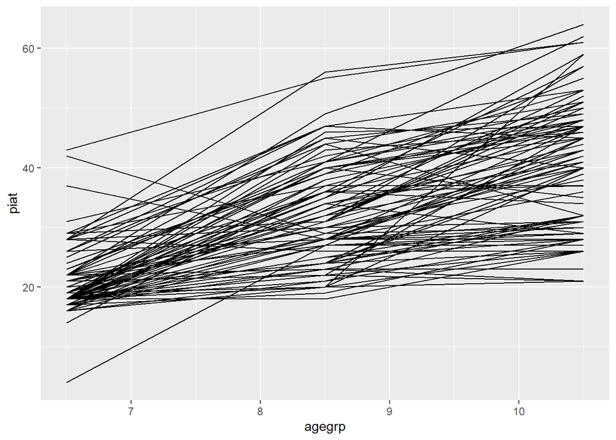

```r
ggplot(reading, aes(agegrp, piat, group = id)) + geom_line()
```

What do you observe?

ANSWER: We see a clear improvement in reading scores, even so is evident that there is a between-child variation. Clearly the observations within an individual are not independent, thus we need to reflect this in our model.

- Obtain the mean of the reading scores at the three time points (i.e. age groups)

```r
score_age = reading %>% group_by(agegrp) %>%
  summarise(mean.piat=mean(piat))
score_age
```

```
## # A tibble: 3 × 2
##   agegrp mean.piat
##    <dbl>     <dbl>
## 1    6.5      20.6
## 2    8.5      32.3
## 3   10.5      40.8
```

# 3. Model with random intecept for each student

The simple and effective way to capture the dependence within child is to build a model with a random intercept. Let $i$ be the student index, for $i=1,\dots,89$ and $j$ be the time index (i.e., time related to the measurements performed at three different ages), for $j=1,2,3$. We assume a Gaussian model for the reading scores and we include a random intercept in the linear predictor:

$$\begin{equation*}
y_{ij} = \beta_0 + \beta_{1}t_j + \alpha_i + \epsilon_{ij}
\end{equation*}$$

where $\beta_0$ and $\beta_1$ are the fixed effects, and are the common intercept and slope for all students. The random intercept is given by $\alpha_i$ and is modelled as $\alpha_i\sim N(0, \sigma^2_{\alpha})$. Finally, $\epsilon_{ij}$ is the error term, with $\epsilon_{ij} \sim N(0, \sigma^2_{\epsilon})$, where $\sigma^2_{\epsilon}$ is the measurement error variance.

- Write the formula and fit the model in `R-INLA` for this model, calling the output as `imod`. In the formula, you can include the random intercept term using `f(id, model="iid")`. Here we use the model `iid` based on the assumption that the students are independent and have a common variance.

```r
formula = piat ~ agegrp + f(id, model="iid")

imod = inla(formula, family="gaussian", data=reading)
```

- Obtain the fixed effects summary

```r
imod$summary.fixed
```

```
##                   mean       sd 0.025quant   0.5quant 0.975quant       mode
## (Intercept) -11.535205 2.254000   -15.9594 -11.535218  -7.110937 -11.535242
## agegrp        5.030579 0.252027     4.5358   5.030581   5.525350   5.030584
##                      kld
## (Intercept) 3.516796e-10
## agegrp      5.642069e-10
```

- How you interpret the coefficient for `agegrp`?

ANSWER: The reading scores increase about five points a year

- Now inspect the hyperparameters, taking advantage of the function `bri.hyperpar.summary` (with argument the name of the model output), which directly converts precisions used internally by INLA to standard deviations (SD); then plot the posterior densities using the function `bri.hyperpar.plot`. Comment the results

```r
# summaries of the hyperparameters
bri.hyperpar.summary(imod)
```

```
##                                      mean        sd   q0.025     q0.5   q0.975
## SD for the Gaussian observations 6.711577 0.3560492 6.047307 6.697981 7.445239
## SD for id                        5.295515 0.6305956 4.139859 5.267850 6.612582
##                                      mode
## SD for the Gaussian observations 6.668493
## SD for id                        5.225590
```

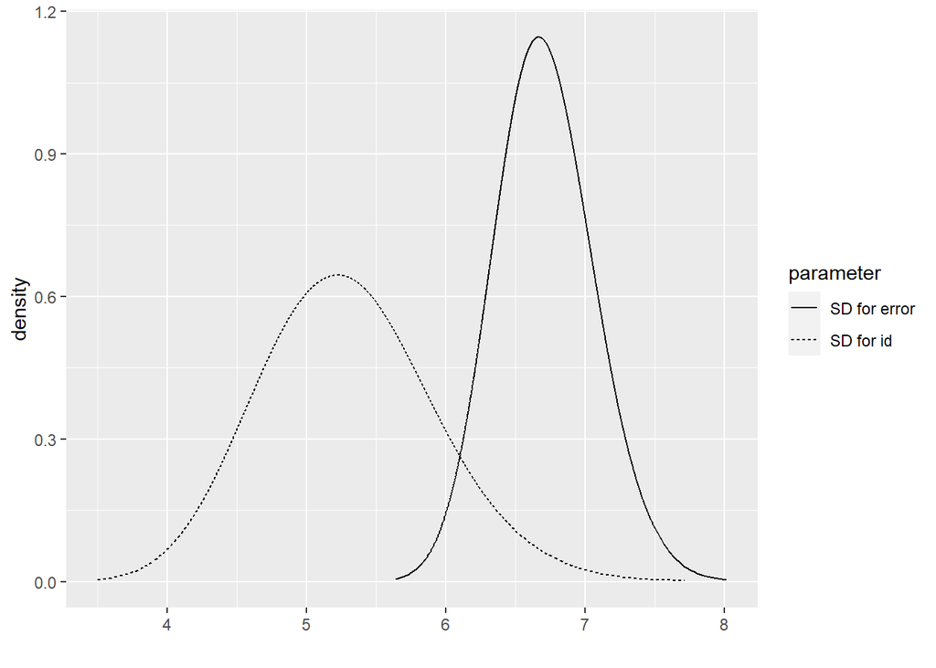

```r
# posterior densities
bri.hyperpar.plot(imod)
```

ANSWER: The posterior mean of $\sigma_{\alpha}$ is about 5, and is similar to that obtained for $\beta_1$, thus the variation between students at a given point in time is comparable to the amount they might be expected to improve over one year. Also, because $\sigma_{\alpha}$ is bigger than zero, we cannot claim the students are all the same.

- The information about individuals can be found in the posterior distributions of the random effects parameters, i.e. $\alpha_i$. These posterior summaries can be found in `imod$summary.random$id`. Try to comment the results

```r
summary(imod$summary.random$id$mean)
```

```
##      Min.   1st Qu.    Median      Mean   3rd Qu.      Max.
## -7.924297 -2.954644 -0.145669 -0.000006  2.663307 14.114872
```

INTERPRETATION: the mean is zero as would be expected given the specification of the model (we assumed an iid Gaussian model centered around 0). From the quartiles, we see that about half the students have mean scores within about [-3, 3] of the overall mean. One student is 14 points above the mean.

# 4. Prediction

### Case study 1

Suppose we have a new student who has scored 18 and 25 at the first two points of measurements, and we are interested in what will happen at the final point of measurement.

To answer this question, we create a data frame with this information and append it to the original data set (which we reload to clear out the additional variables we created above):

```r
data(reading, package="brinla")
reading$id = as.numeric(reading$id)
newsub = data.frame(id=90, agegrp = c(6.5,8.5,10.5),
              piat=c(18, 25, NA))
nreading = rbind(reading, newsub)
```

- Refit the model as before, but now include the option `control.predictor = list(compute=TRUE)` to compute the posterior means of the linear predictors and `control.compute=list(return.marginals.predictor=TRUE)` to obtain the marginals of the linear predictor

```r
formula = piat ~ agegrp + f(id, model="iid")

imod = inla(formula, family="gaussian", data=nreading,
            control.predictor = list(compute=TRUE),
            control.compute=list(return.marginals.predictor=TRUE))
```

- There are $90 \times 3 = 270$ cases in the data. Only the last of these has an unknown response. You can access the posterior distribution for this fitted value (the linear predictor) using the function `marginals.fitted.values` (call the output as `pm90`)

```r
pm90 = imod$marginals.fitted.values[[270]]
```

- Now plot the posterior distribution as follows:

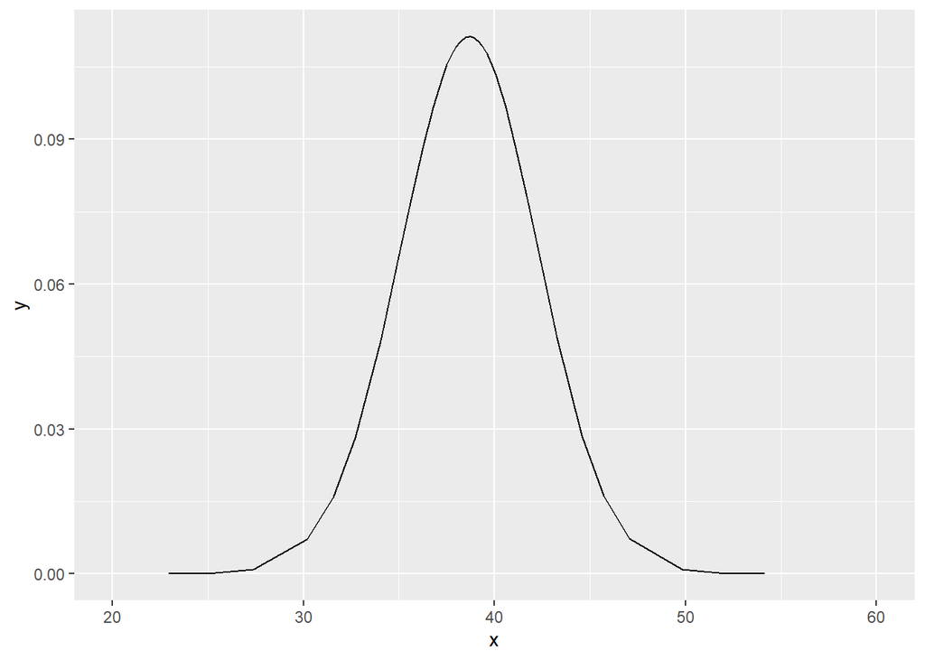

```r
p1 = ggplot(data.frame(pm90),aes(x,y))+geom_line()+xlim(c(20,60))
p1
```

### Case study 2

Now assume that we don’t have any information on the new student, and that all the data on `piat` response variable are missing.

- Reload the data as in the previous section, and set all the new data for the 90-th student as missing, modifing the code given in the previous section

```r
data(reading, package="brinla")
reading$id = as.numeric(reading$id)

newsub = data.frame(id=90, agegrp = c(6.5,8.5,10.5),
                  piat=c(NA, NA, NA))
nreading = rbind(reading, newsub)
```

- Refit the model again and construct the prediction. Call the new model results as `imodq`

```r
formula = piat ~ agegrp + f(id, model="iid")
imodq = inla(formula, family="gaussian", data=nreading,
              control.predictor = list(compute=TRUE),
              control.compute=list(return.marginals.predictor=TRUE))
```

- Inspect the posterior distribution for this fitted value as we did before

```r
qm90 = imodq$marginals.fitted.values[[270]]
```

- Finally, we plot the predictive distributions for individual with partial response information (solid) and no response information (dashed)

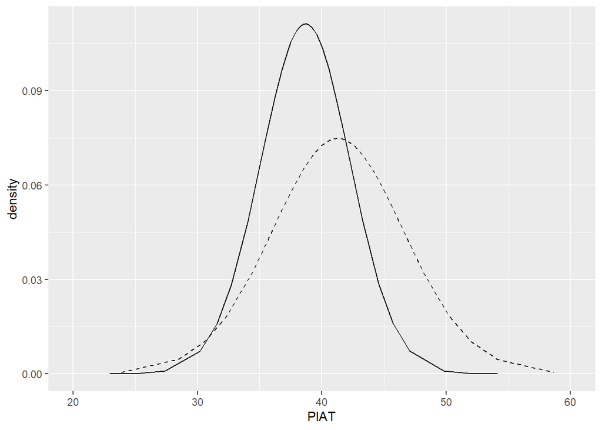

```r
p1 + geom_line(data=data.frame(qm90),aes(x=x,y=y),linetype=2)+xlab("PIAT")+ylab("density")
```

- How would you interpret these results?

Answer: We see that for the first individual, who has achieved relatively weak reading scores at the first two time-points, the predictive distribution is shifted below the overall mean of 40.8 expected at age 10.5 years. In contrast, we see that the predictive distribution for the individual without known response information is centered on this expected mean. For the former distribution, we have some information about the student so the prediction is better (has a more concentrated distribution). Instead, we have no information in the latter case, so the predictive distribution has greater spread.

# References

Singer, Judith D, and John B Willett. 2003. *Applied Longitudinal Data Analysis: Modeling Change and Event Occurrence*. Oxford university press.

Wang, Xiaofeng, Yuryan Yue, and Julian J Faraway. 2018. *Bayesian Regression Modeling with INLA*. Chapman; Hall/CRC.